# Summarise GWAS results

Malachy Campbell

8/7/2018

# Background

Here, we’ll generate a quick summary of the GWAS results, make some manhattan plots, and compare marker effects between RR and TP approaches.

# Sumarise RR and TP results

Here, we determined how many SNPs showed a significant ($p < 1 \times 10^{-4}$) association at one or more time points. A significance threshold was selected based on the criteria used by [Zhao et al (2011)](https://www.nature.com/articles/ncomms1467). A very small number was added to all $p$-values to correct for those that had a $p$-value of 0. This was to ensure that $-log_{10}(p)$ would return a real number.

```r
TP.p <- as.matrix( read.table("/Users/malachycampbell/Desktop/RRgwas_git/CompCluster/TP/pvals.txt", sep = "\t", header = T, row.names = 1) )
RR.p <- as.matrix( read.table("/Users/malachycampbell/Desktop/RRgwas_git/CompCluster/RR/pvals.txt", sep = "\t", header = T, row.names = 1) )
RR.p <- RR.p + 1E-10
TP.p <- TP.p + 1E-10

MAP <- read.table("/Users/malachycampbell/Desktop/RRgwas_git/CompCluster/MAP_maf0.05.txt", header = F, sep = "\t")

row.names(TP.p) <- MAP$V2
row.names(RR.p) <- MAP$V2

#Take the significant SNPs from RR GWAS and TP GWAS and store the names in an array
RR.array <- array()
TP.array <- array()

for (i in 1:20){
  if(i == 1){
    RR.array <- row.names(RR.p[RR.p[,i] < 1E-4 ,])
    TP.array <- row.names(TP.p[TP.p[,i] < 1E-4 ,])
  }else{
    RR.array <- c(RR.array, row.names(RR.p[RR.p[,i] < 1E-4 ,]) )
    TP.array <- c(TP.array, row.names(TP.p[TP.p[,i] < 1E-4 ,]) )
  }
}

length(unique(RR.array))
```

```
## [1] 717
```

```r
length(unique(TP.array))
```

```
## [1] 379
```

# Compare SNP effects between RR and TP approaches

The following code was used to examine the relationship between the SNP effects from the two approaches (RR and TP).

```r
library(reshape2)

#load the files
TP.p <- as.matrix( read.table("/Users/malachycampbell/Desktop/RRgwas_git/CompCluster/TP/pvals.txt", sep = "\t", header = T, row.names = 1) )
RR.p <- as.matrix( read.table("/Users/malachycampbell/Desktop/RRgwas_git/CompCluster/RR/pvals.txt", sep = "\t", header = T, row.names = 1) )
RR.p <- RR.p + 1E-10
TP.p <- TP.p + 1E-10

TP.beta <- as.matrix( read.csv("/Users/malachycampbell/Desktop/RRgwas_git/CompCluster/TP/Eff.mat.csv") )
RR.beta <- as.matrix( read.csv("/Users/malachycampbell/Desktop/RRgwas_git/CompCluster/RR/Eff.mat.csv") )

MAP <- read.table("/Users/malachycampbell/Desktop/RRgwas_git/CompCluster/MAP_maf0.05.txt", header = F, sep = "\t")

#add SNP names and days to p and beta matrices
row.names(TP.p) <- MAP$V2
row.names(RR.p) <- MAP$V2

row.names(TP.beta) <- MAP$V2
row.names(RR.beta) <- MAP$V2

colnames(TP.p) <- paste0("D", 1:20)
colnames(RR.p) <- paste0("D", 1:20)

colnames(TP.beta) <- paste0("D", 1:20)
colnames(RR.beta) <- paste0("D", 1:20)

#Convert the p values and snp effects to long format
TP.p <- melt(TP.p, id.vars = 0)
TP.beta <- melt(TP.beta, id.vars = 0)

RR.p <- melt(RR.p, id.vars = 0)
RR.beta <- melt(RR.beta, id.vars = 0)

#Make a column called Key to provide a unique identifier for the SNP and day
RR.p$Key <- paste0(RR.p$Var1, "_", RR.p$Var2)
RR.beta$Key <- paste0(RR.beta$Var1, "_", RR.beta$Var2)

TP.p$Key <- paste0(TP.p$Var1, "_", TP.p$Var2)
TP.beta$Key <- paste0(TP.beta$Var1, "_", TP.beta$Var2)

#Check the correlation for all SNPs
cor(abs(TP.beta$value), abs(RR.beta$value))
```

```
## [1] 0.8470621
```

```r
#0.8470479

#Select only the signifant SNPs
Sig.TP <- unique(TP.p[TP.p$value < 1E-4 ,]$Var1)
Sig.RR <- unique(RR.p[RR.p$value < 1E-4 ,]$Var1)

#Get the min and max effects for signficant SNPs from both approaches
min(RR.beta[RR.beta$Var1 %in% Sig.RR ,]$value) #-309.6
```

```
## [1] -309.6358
```

```r
max(RR.beta[RR.beta$Var1 %in% Sig.RR ,]$value) #366.3
```

```
## [1] 366.2813
```

```r
min(TP.beta[TP.beta$Var1 %in% Sig.TP ,]$value) #-106.0
```

```
## [1] -106.0383
```

```r
max(TP.beta[TP.beta$Var1 %in% Sig.TP ,]$value) #114.3
```

```
## [1] 114.3228
```

```r
Sig.TP <- TP.p[TP.p$value < 1E-4 ,]$Key
Sig.RR <- RR.p[RR.p$value < 1E-4 ,]$Key
```

## Plot SNP effects for RR and TP approaches

This code was used to create figure 1.

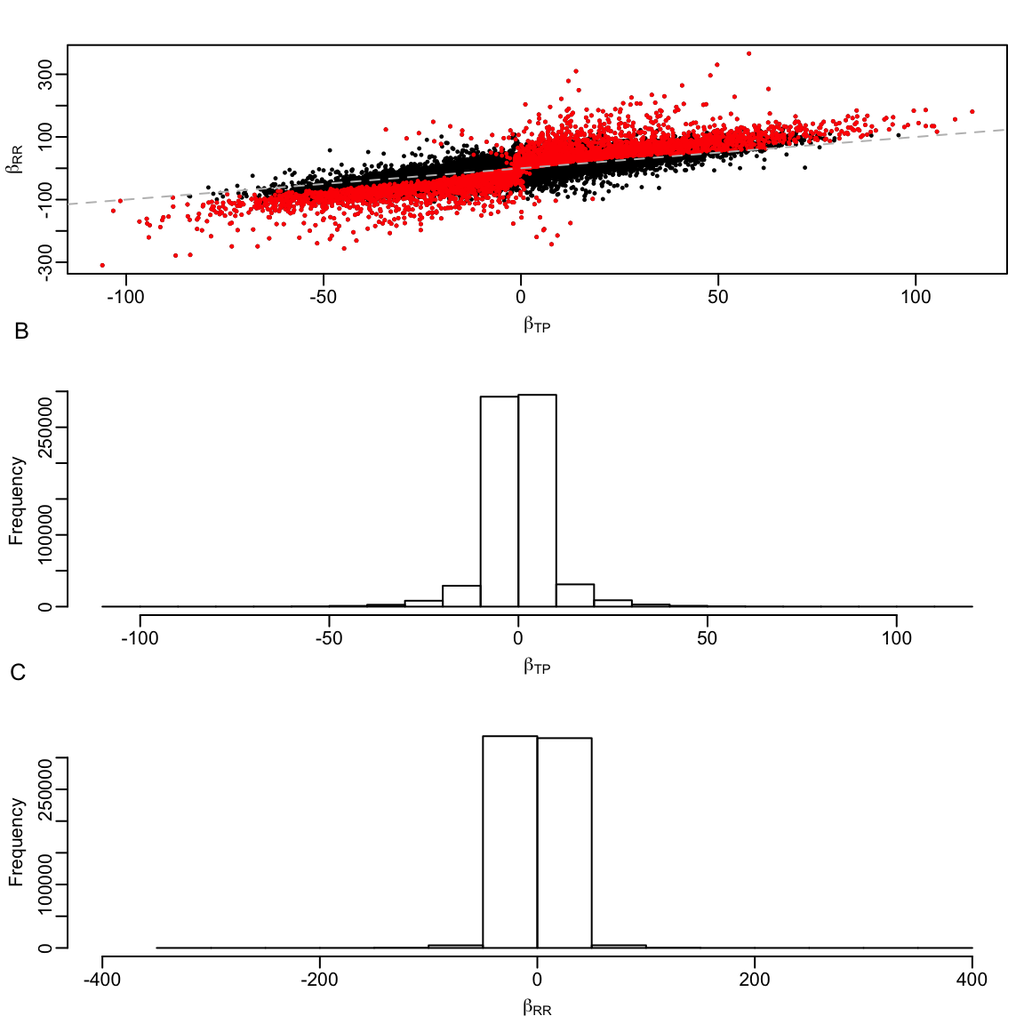

```r
#pdf("/Users/malachycampbell/Desktop/RRgwas_git/Figures/Fig1.pdf", h=6, w=3.25, useDingbats = F, pointsize = 10)
par(mar=c(3,3,2,.75), mgp=c(1.8,0.5,0))
nf = layout(rbind(c(1,1), c(2,2), c(3,3)))

plot(TP.beta$value, RR.beta$value, pch = 19, cex = 0.3, xlab = expression(beta["TP"]), ylab = expression(beta["RR"]) )

points(TP.beta[TP.beta$Key %in% Sig.RR ,]$value,
            RR.beta[RR.beta$Key %in% Sig.RR ,]$value,
            pch = 19, cex = 0.3, col = "red")

abline(c(0,1), col = "grey", lty = 2)

mtext("A", 2,  adj=3.5, las=1, padj=-10, font=1, cex=0.8)

##
hist(TP.beta$value, main = "", xlab = expression(beta["TP"]))

mtext("B", 2,  adj=3.5, las=1, padj=-10, font=1, cex=0.8)

##
hist(RR.beta$value, main = "", xlab = expression(beta["RR"]), xlim = c(-400, 400))
mtext("C", 2,  adj=3.5, las=1, padj=-10, font=1, cex=0.8)
```

```r
#dev.off()
```

# Manhattan Plots

This code was used to generate a manhattan plot of SNP effects ($|\beta|$) for the RR and TP approaches. The script uses a manhattan plot function that was modified from Stephen Turner’s code he posted a few years back ([check it out here](http://www.gettinggeneticsdone.com/2011/04/annotated-manhattan-plots-and-qq-plots.html)). The modified function plots the $|\beta|$ rather than $-log_{10}(p)$.

```r
manhattan.Beta <- function(dataframe, colors = c("gray10", "gray50"), ymax = "max", xaxis.cex = 1, yaxis.cex = 1, limitchromosomes = 1:23, suggestiveline = NULL, genomewideline = NULL, annotate=NULL, Title, ...) {

  d=dataframe
  ymax=max(d$Beta)
  ymin=min(d$Beta)

  #throws error if you don't have columns named CHR, BP, and P in your data frame.
  if (!("CHR" %in% names(d) & "BP" %in% names(d) & "Beta" %in% names(d))) stop("Make sure your data frame contains columns CHR, BP, and Beta")

  # limits chromosomes to plot. (23=x, 24=y, 25=par?, 26=mito?)
  if (any(limitchromosomes)) d=d[d$CHR %in% limitchromosomes, ]

  # remove na's, sort by CHR and BP, and keep snps where 0<P<=1
  d = d[order(d$CHR, d$BP), ]

  # sets colors based on colors argument.
  colors <- rep(colors,max(d$CHR))[1:max(d$CHR)]

  # sets the maximum value on the y axis
  if (ymax == "max") ymax<-ceiling(max(d$Beta))

  # creates continuous position markers for x axis for entire chromosome. also creates tick points.
  d$pos = NA
  ticks = NULL
  lastbase = 0
  numchroms = length(unique(d$CHR))
  for (i in unique(d$CHR)) {
    if (i == 1) {
      d[d$CHR == i, ]$pos = d[d$CHR == i, ]$BP
    } else {
      lastbase=lastbase+tail(subset(d,CHR==i-1)$BP, 1)
      d[d$CHR == i, ]$pos = d[d$CHR == i, ]$BP+lastbase
    }
    ticks=c(ticks, d[d$CHR == i, ]$pos[floor(length(d[d$CHR == i, ]$pos)/2)+1])
  }


  # create the plot
  # creates a blank plot
  with(d, plot(pos, Beta, ylim = c(0,ymax), ylab = expression("|" ~ beta ~ "|"), xlab = "Chromosome", xaxt = "n", type = "n", cex = 0.3, yaxt = "n", main = Title, ...))
  # then make an axis that has chromosome number instead of position
  axis(1, at = ticks, lab = unique(d$CHR), cex.axis = xaxis.cex)
  axis(2, cex.axis = yaxis.cex)
  icol=1
  for (i in unique(d$CHR)) {
    with(d[d$CHR==i, ],points(pos, Beta, col=colors[icol], cex=0.3, ...))
    icol = icol+1
  }

  # create a new data frame with rows from the original data frame where SNP is in annotate character vector.
  # then plot those points over the original graph, but with a larger point size and a different color.
  if (!is.null(annotate)) {
    d.annotate=d[which(d$SNP %in% annotate), ]
    icol=1
    for (i in unique(d.annotate$CHR)) {
      with(d.annotate[d.annotate$CHR==i, ], points(pos, Beta, col = "red", cex=0.5, pch = 20, ...))
      icol = icol+1
    }
  }

  # add threshold lines
  if (!is.null(suggestiveline)) abline(h=suggestiveline, col="blue")
  if (!is.null(genomewideline)) abline(h=genomewideline, col="red")
}
```

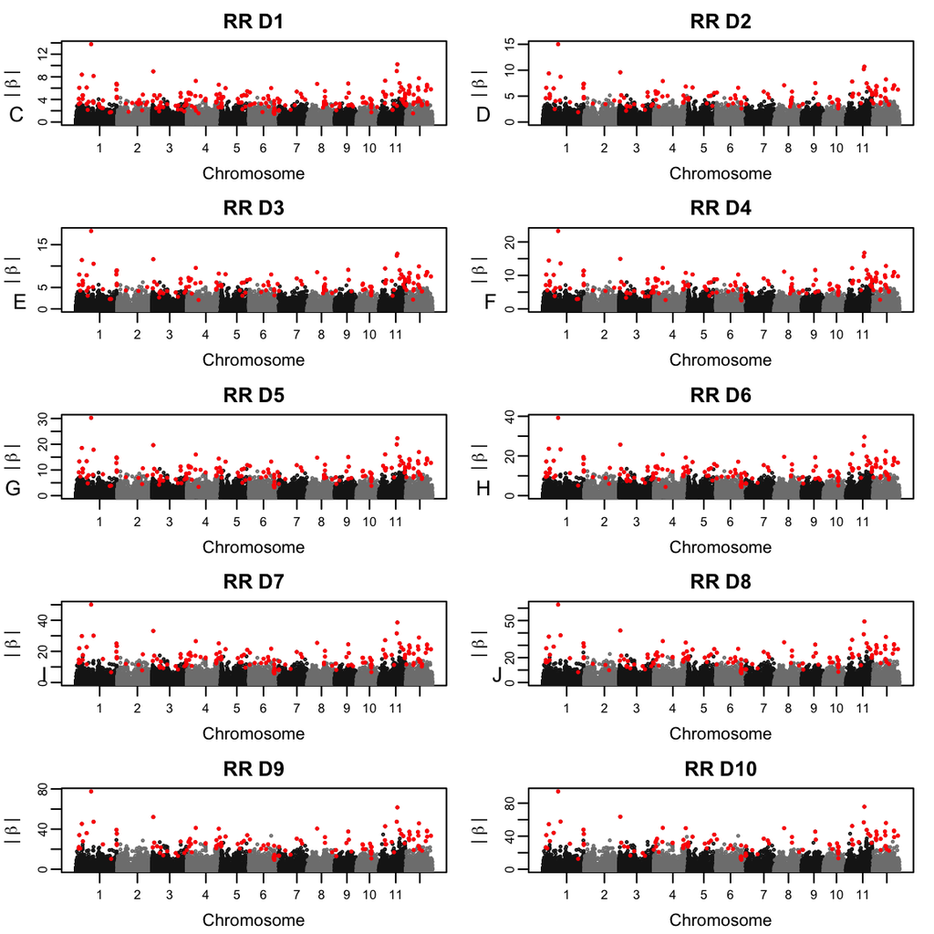

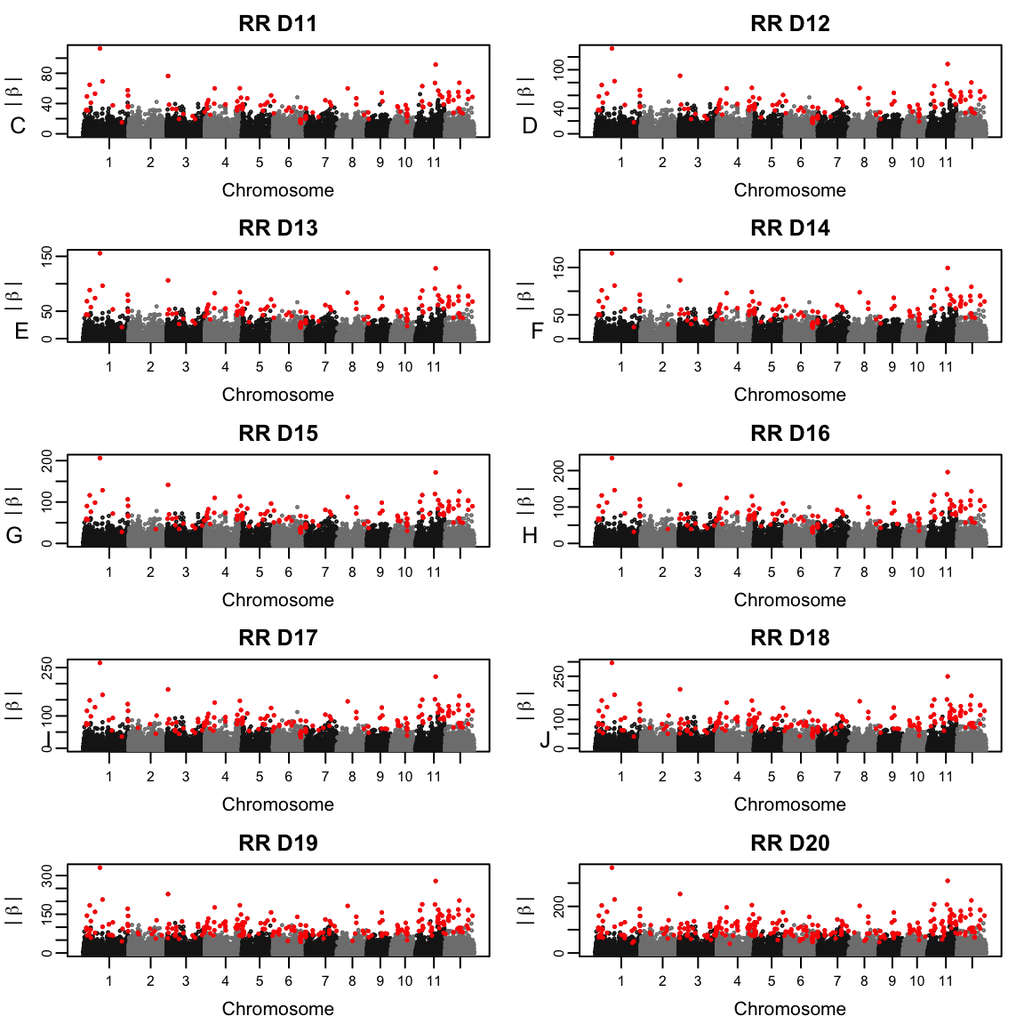

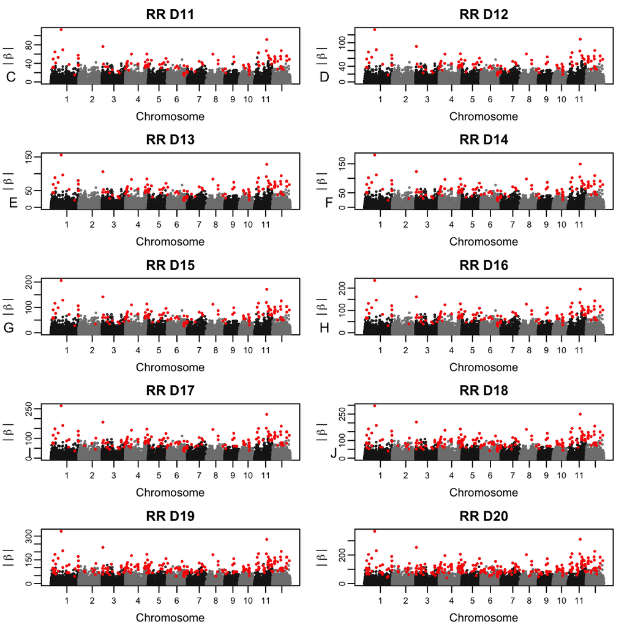

```r
library(reshape2)

TP.p <- as.matrix( read.table("/Users/malachycampbell/Desktop/RRgwas_git/CompCluster/TP/pvals.txt", sep = "\t", header = T, row.names = 1) )
RR.p <- as.matrix( read.table("/Users/malachycampbell/Desktop/RRgwas_git/CompCluster/RR/pvals.txt", sep = "\t", header = T, row.names = 1) )
RR.p <- RR.p + 1E-10
TP.p <- TP.p + 1E-10

MAP <- read.table("/Users/malachycampbell/Desktop/RRgwas_git/CompCluster/MAP_maf0.05.txt", header = F, sep = "\t")

TP.beta <- as.matrix( read.csv("/Users/malachycampbell/Desktop/RRgwas_git/CompCluster/TP/Eff.mat.csv") )
RR.beta <- as.matrix( read.csv("/Users/malachycampbell/Desktop/RRgwas_git/CompCluster/RR/Eff.mat.csv") )

row.names(TP.p) <- MAP$V2
row.names(RR.p) <- MAP$V2

row.names(TP.beta) <- MAP$V2
row.names(RR.beta) <- MAP$V2

Sig.RR.p <- melt(RR.p, id.vars = 0)
Sig.RR.p$Var2 <- as.numeric(as.character(sub("V", "", Sig.RR.p$Var2)))
Sig.RR.p <- Sig.RR.p[Sig.RR.p$value < 1E-04 ,]

Sig.TP.p <- melt(TP.p, id.vars = 0)
Sig.TP.p$Var2 <- as.numeric(as.character(sub("V", "", Sig.TP.p$Var2)))
Sig.TP.p <- Sig.TP.p[Sig.TP.p$value < 1E-04 ,]


for (i in 1:20){
  if(i < 10){
    #pdf("/Users/malachycampbell/Desktop/RRgwas_git/Figures/FigS1.pdf", h=10, w=7, useDingbats = F, pointsize = 10)
    par(mar=c(3,3,2,1), mgp=c(1.8,0.5,0))
    nf = layout(rbind(c(1,2), c(3,4), c(5,6), c(7,8), c(9,10)))

    for (i in 1:10){
      tmp.Sig <- Sig.RR.p[Sig.RR.p$Var2 == i ,]
      tmp.RR <- cbind(MAP, RR.beta[,i])
      colnames(tmp.RR) <- c("CHR", "SNP", "CM", "BP", "Beta")
      manhattan.Beta(tmp.RR, Title = paste0("RR D", i), annotate = tmp.Sig$Var1, xaxis.cex = 0.75, yaxis.cex = 0.75)
      mtext(LETTERS[i], 2,  adj=3.5, las=1, padj=-10, font=1, cex=0.8)

    }
    #dev.off()
    }else{
    #pdf("/Users/malachycampbell/Desktop/RRgwas_git/Figures/FigS2.pdf", h=10, w=7, useDingbats = F, pointsize = 10)
    par(mar=c(3,3,2,1), mgp=c(1.8,0.5,0))
    nf = layout(rbind(c(1,2), c(3,4), c(5,6), c(7,8), c(9,10)))

    for (i in 11:20){
      tmp.Sig <- Sig.RR.p[Sig.RR.p$Var2 == i ,]
      tmp.RR <- cbind(MAP, RR.beta[,i])
      colnames(tmp.RR) <- c("CHR", "SNP", "CM", "BP", "Beta")
      manhattan.Beta(tmp.RR, Title = paste0("RR D", i), annotate = tmp.Sig$Var1, xaxis.cex = 0.75, yaxis.cex = 0.75)
      mtext(LETTERS[i-10], 2,  adj=3.5, las=1, padj=-10, font=1, cex=0.8)
    }
    #dev.off()
    }
  }
```

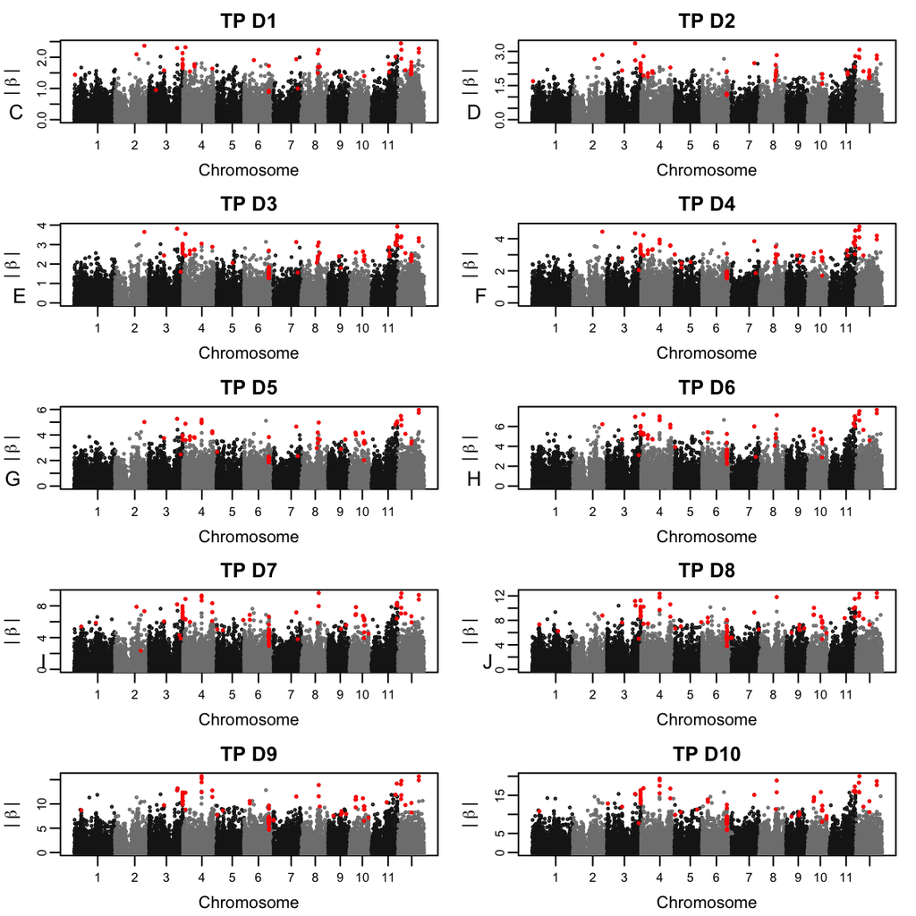

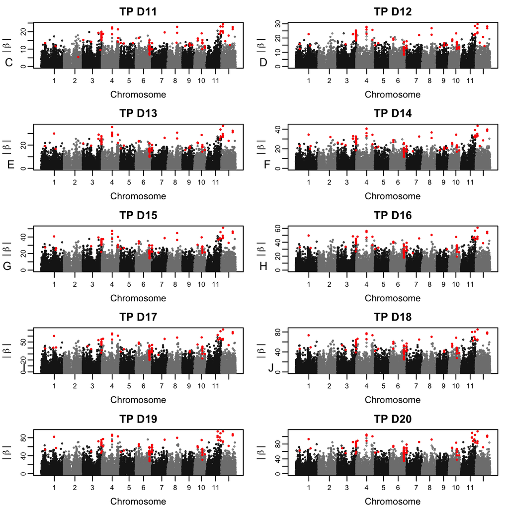

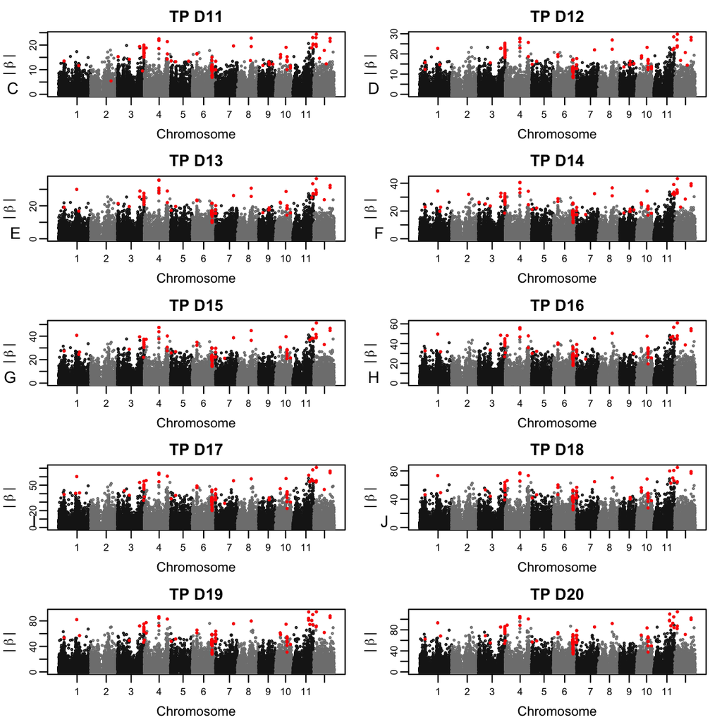

```r
for (i in 1:20){
  if(i < 10){
    #pdf("/Users/malachycampbell/Desktop/RRgwas_git/Figures/FigS3.pdf", h=10, w=7, useDingbats = F, pointsize = 10)
    par(mar=c(3,3,2,1), mgp=c(1.8,0.5,0))
    nf = layout(rbind(c(1,2), c(3,4), c(5,6), c(7,8), c(9,10)))

    for (i in 1:10){
      tmp.Sig <- Sig.TP.p[Sig.TP.p$Var2 == i ,]
      tmp.TP <- cbind(MAP, TP.beta[,i])
      colnames(tmp.TP) <- c("CHR", "SNP", "CM", "BP", "Beta")
      manhattan.Beta(tmp.TP, Title = paste0("TP D", i), annotate = tmp.Sig$Var1, xaxis.cex = 0.75, yaxis.cex = 0.75)
      mtext(LETTERS[i], 2,  adj=3.5, las=1, padj=-10, font=1, cex=0.8)

    }
    #dev.off()
    }else{
    #pdf("/Users/malachycampbell/Desktop/RRgwas_git/Figures/FigS4.pdf", h=10, w=7, useDingbats = F, pointsize = 10)
    par(mar=c(3,3,2,1), mgp=c(1.8,0.5,0))
    nf = layout(rbind(c(1,2), c(3,4), c(5,6), c(7,8), c(9,10)))

    for (i in 11:20){
      tmp.Sig <- Sig.TP.p[Sig.TP.p$Var2 == i ,]
      tmp.TP <- cbind(MAP, TP.beta[,i])
      colnames(tmp.TP) <- c("CHR", "SNP", "CM", "BP", "Beta")
      manhattan.Beta(tmp.TP, Title = paste0("TP D", i), annotate = tmp.Sig$Var1, xaxis.cex = 0.75, yaxis.cex = 0.75)
      mtext(LETTERS[i-10], 2,  adj=3.5, las=1, padj=-10, font=1, cex=0.8)
    }
    #dev.off()
    }
  }
```

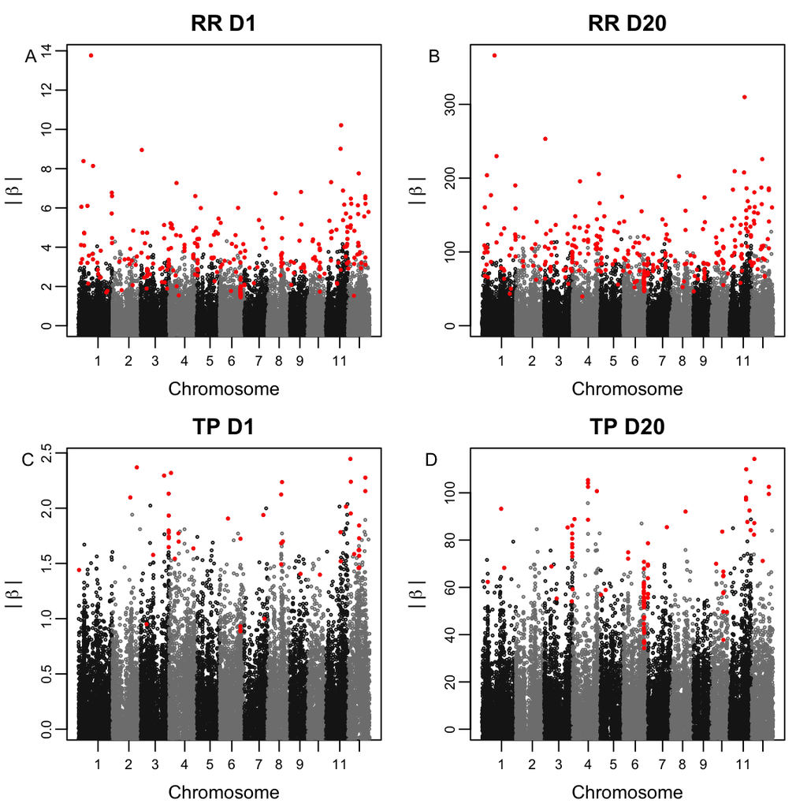

```r
#pdf("/Users/malachycampbell/Desktop/RRgwas_git/Figures/Fig2.pdf", h=4, w=7, useDingbats = F, pointsize = 10)
par(mar=c(3,3,2,1), mgp=c(1.8,0.5,0))
nf = layout(rbind(c(1,2), c(3,4)))

tmp.Sig <- Sig.RR.p[Sig.RR.p$Var2 == 1 ,]
tmp.RR <- cbind(MAP, RR.beta[,1])
colnames(tmp.RR) <- c("CHR", "SNP", "CM", "BP", "Beta")
manhattan.Beta(tmp.RR, Title = "RR D1", annotate = tmp.Sig$Var1, xaxis.cex = 0.75, yaxis.cex = 0.75)

mtext("A", 2,  adj=3.5, las=1, padj=-10, font=1, cex=0.8)


tmp.Sig <- Sig.RR.p[Sig.RR.p$Var2 == 20 ,]
tmp.RR <- cbind(MAP, RR.beta[,20])
colnames(tmp.RR) <- c("CHR", "SNP", "CM", "BP", "Beta")
manhattan.Beta(tmp.RR, Title = "RR D20", annotate = tmp.Sig$Var1, xaxis.cex = 0.75, yaxis.cex = 0.75)

mtext("B", 2,  adj=3.5, las=1, padj=-10, font=1, cex=0.8)


tmp.Sig <- Sig.TP.p[Sig.TP.p$Var2 == 1 ,]
tmp.TP <- cbind(MAP, TP.beta[,1])
colnames(tmp.TP) <- c("CHR", "SNP", "CM", "BP", "Beta")
manhattan.Beta(tmp.TP, Title = "TP D1", annotate = tmp.Sig$Var1, xaxis.cex = 0.75, yaxis.cex = 0.75)

mtext("C", 2,  adj=3.5, las=1, padj=-10, font=1, cex=0.8)


tmp.Sig <- Sig.TP.p[Sig.TP.p$Var2 == 20 ,]
tmp.TP <- cbind(MAP, TP.beta[,20])
colnames(tmp.TP) <- c("CHR", "SNP", "CM", "BP", "Beta")
manhattan.Beta(tmp.TP, Title = "TP D20", annotate = tmp.Sig$Var1, xaxis.cex = 0.75, yaxis.cex = 0.75)

mtext("D", 2,  adj=3.5, las=1, padj=-10, font=1, cex=0.8)
```

```r
#dev.off()
```